# Project: No-Show Medical Appointments

Author: Piyush Kumar

### Table of Contents:

- Introduction
- Data Wrangling
- Exploratory Data Analysis
- Conclusions

### Introduction:

A person makes a doctor appointment, receives all the instructions and no-show. Who to blame?

The dataset under investigation contains information about 100k medical appointments in Brazil and is focused on the question of whether or not patients show up for their appointment. A number of characteristics are included in the dataset.

- PatientId - Identification of a patient
- AppointmentID - Identification of each appointment
- Gender - Male or Female. Female is the greater proportion, woman takes way more care of they health in comparison to man.
- AppointmentDay - The day of the actual appointment, when they have to visit the doctor.
- ScheduledDay -The day someone called or registered the appointment, this is before appointment of course.
- Age - How old is the patient.
- Neighbourhood - Location of the hospital
- Scholarship - True of False. Whether or not the patient is enrolled in Brazilian welfare program [Bolsa Família](https://en.wikipedia.org/wiki/Bolsa_Fam%C3%ADlia).
- Hipertension - True or False. High Blood Pressure Condition
- Diabetes - True or False
- Alcoholism - True or False
- Handcap - True or False
- SMS_received - 1 or more messages sent to the patient.
- No-show - True or False.

### Research Questions:

- What is the distribution of patients who showed up on appointment Vs who didn't?
- What is the age distribution of patients who made it to appointments Vs who didn't?
- What is the gender distribution of patients who made it to appointments Vs who didn't.
- Is there any correlation among age, gender and no. of appointments?
- How does health condition of a patient impacts No-Shows?
- How does scheduled day of the week compare with No-Shows?
- What hour of the day receives most appointments?
- Which neighborhoods have the highest number of No-Shows?
- What is the breakdown of No-Shows versus shows by patients that received SMS reminders?
- What is the impact of having scholarship program on patient No-Shows.

To get started, let's import our libraries

```python
import pandas as pd
import numpy as np
import matplotlib.pyplot as plt
%matplotlib inline
import seaborn as sns
sns.set_style('darkgrid')
```

```python
# Let's load our dataset and read in top few rows.

df=pd.read_csv('noshowappointments.csv')
df.head()
```

|  | PatientId | AppointmentID | Gender | ScheduledDay | AppointmentDay | Age | Neighbourhood | Scholarship | Hipertension | Diabetes | Alcoholism | Handcap | SMS_received | No-show |
| --- | --- | --- | --- | --- | --- | --- | --- | --- | --- | --- | --- | --- | --- | --- |
| 0 | 2.987250e+13 | 5642903 | F | 2016-04-29T18:38:08Z | 2016-04-29T00:00:00Z | 62 | JARDIM DA PENHA | 0 | 1 | 0 | 0 | 0 | 0 | No |
| 1 | 5.589978e+14 | 5642503 | M | 2016-04-29T16:08:27Z | 2016-04-29T00:00:00Z | 56 | JARDIM DA PENHA | 0 | 0 | 0 | 0 | 0 | 0 | No |
| 2 | 4.262962e+12 | 5642549 | F | 2016-04-29T16:19:04Z | 2016-04-29T00:00:00Z | 62 | MATA DA PRAIA | 0 | 0 | 0 | 0 | 0 | 0 | No |
| 3 | 8.679512e+11 | 5642828 | F | 2016-04-29T17:29:31Z | 2016-04-29T00:00:00Z | 8 | PONTAL DE CAMBURI | 0 | 0 | 0 | 0 | 0 | 0 | No |
| 4 | 8.841186e+12 | 5642494 | F | 2016-04-29T16:07:23Z | 2016-04-29T00:00:00Z | 56 | JARDIM DA PENHA | 0 | 1 | 1 | 0 | 0 | 0 | No |

- All the columns seems useful, we won't be removing any columns.
- However, there are inconsistencies with the column headers, this needs to be changed to make it more readable and easier to work with.

```python
# let's get the shape of our datset.

df.shape
```

```
(110527, 14)
```

```python
# Let's check for duplicates in the dataset.

df.duplicated().sum()
```

```
0
```

```python
# let's check for the nulls in the dataset.

df.isnull().sum()
```

```
PatientId         0
AppointmentID     0
Gender            0
ScheduledDay      0
AppointmentDay    0
Age               0
Neighbourhood     0
Scholarship       0
Hipertension      0
Diabetes          0
Alcoholism        0
Handcap           0
SMS_received      0
No-show           0
dtype: int64
```

```python
# let's get the broadview of our dataset.

df.info()
```

```
<class 'pandas.core.frame.DataFrame'>
RangeIndex: 110527 entries, 0 to 110526
Data columns (total 14 columns):
PatientId         110527 non-null float64
AppointmentID     110527 non-null int64
Gender            110527 non-null object
ScheduledDay      110527 non-null object
AppointmentDay    110527 non-null object
Age               110527 non-null int64
Neighbourhood     110527 non-null object
Scholarship       110527 non-null int64
Hipertension      110527 non-null int64
Diabetes          110527 non-null int64
Alcoholism        110527 non-null int64
Handcap           110527 non-null int64
SMS_received      110527 non-null int64
No-show           110527 non-null object
dtypes: float64(1), int64(8), object(5)
memory usage: 11.8+ MB
```

- There are no nulls and duplicates in the dataset.
- PatientID and AppointmentID is of incorrect data type. This needs to be changed to object type.
- ScheduledDay and AppointmentDay are of object type instead of datetime.
- AppointmentDay doesn't really have any time component, we can remove that.

```python
#let's get the summary statistics for our dataset

df.describe()
```

|  | PatientId | AppointmentID | Age | Scholarship | Hipertension | Diabetes | Alcoholism | Handcap | SMS_received |
| --- | --- | --- | --- | --- | --- | --- | --- | --- | --- |
| count | 1.105270e+05 | 1.105270e+05 | 110527.000000 | 110527.000000 | 110527.000000 | 110527.000000 | 110527.000000 | 110527.000000 | 110527.000000 |
| mean | 1.474963e+14 | 5.675305e+06 | 37.088874 | 0.098266 | 0.197246 | 0.071865 | 0.030400 | 0.022248 | 0.321026 |
| std | 2.560949e+14 | 7.129575e+04 | 23.110205 | 0.297675 | 0.397921 | 0.258265 | 0.171686 | 0.161543 | 0.466873 |
| min | 3.921784e+04 | 5.030230e+06 | -1.000000 | 0.000000 | 0.000000 | 0.000000 | 0.000000 | 0.000000 | 0.000000 |
| 25% | 4.172614e+12 | 5.640286e+06 | 18.000000 | 0.000000 | 0.000000 | 0.000000 | 0.000000 | 0.000000 | 0.000000 |
| 50% | 3.173184e+13 | 5.680573e+06 | 37.000000 | 0.000000 | 0.000000 | 0.000000 | 0.000000 | 0.000000 | 0.000000 |
| 75% | 9.439172e+13 | 5.725524e+06 | 55.000000 | 0.000000 | 0.000000 | 0.000000 | 0.000000 | 0.000000 | 1.000000 |
| max | 9.999816e+14 | 5.790484e+06 | 115.000000 | 1.000000 | 1.000000 | 1.000000 | 1.000000 | 4.000000 | 1.000000 |

- Handcap variable has max value as 4 while this can take up only 0 or 1.
- Age variable has min value as -1, all such rows needs to be removed from the dataframe.

### Data Wrangling:

```python
#  Changing column headers for readability and accessability.

headers = ['patient_id',
           'appointment_id',
           'gender',
           'scheduled_day',
           'appointment_day',
           'age',
           'neighborhood',
           'scholarship',
           'hypertension',
           'diabetes',
           'alcoholism',
           'handicap',
           'sms_received',
           'no_show']

df.columns = headers
df.head()
```

|  | patient_id | appointment_id | gender | scheduled_day | appointment_day | age | neighborhood | scholarship | hypertension | diabetes | alcoholism | handicap | sms_received | no_show |
| --- | --- | --- | --- | --- | --- | --- | --- | --- | --- | --- | --- | --- | --- | --- |
| 0 | 2.987250e+13 | 5642903 | F | 2016-04-29T18:38:08Z | 2016-04-29T00:00:00Z | 62 | JARDIM DA PENHA | 0 | 1 | 0 | 0 | 0 | 0 | No |
| 1 | 5.589978e+14 | 5642503 | M | 2016-04-29T16:08:27Z | 2016-04-29T00:00:00Z | 56 | JARDIM DA PENHA | 0 | 0 | 0 | 0 | 0 | 0 | No |
| 2 | 4.262962e+12 | 5642549 | F | 2016-04-29T16:19:04Z | 2016-04-29T00:00:00Z | 62 | MATA DA PRAIA | 0 | 0 | 0 | 0 | 0 | 0 | No |
| 3 | 8.679512e+11 | 5642828 | F | 2016-04-29T17:29:31Z | 2016-04-29T00:00:00Z | 8 | PONTAL DE CAMBURI | 0 | 0 | 0 | 0 | 0 | 0 | No |
| 4 | 8.841186e+12 | 5642494 | F | 2016-04-29T16:07:23Z | 2016-04-29T00:00:00Z | 56 | JARDIM DA PENHA | 0 | 1 | 1 | 0 | 0 | 0 | No |

```python
# Changing the datatypes of patient_id, appointment_id, scheduled_day and appointment_day columns.

df['patient_id'] = df['patient_id'].astype('int64').astype('object')
df['appointment_id'] = df['appointment_id'].astype('object')
df['scheduled_day'] = pd.to_datetime(df['scheduled_day'])
df['appointment_day'] = pd.to_datetime(df['appointment_day'])

df.info()
```

```
<class 'pandas.core.frame.DataFrame'>
RangeIndex: 110527 entries, 0 to 110526
Data columns (total 14 columns):
patient_id         110527 non-null object
appointment_id     110527 non-null object
gender             110527 non-null object
scheduled_day      110527 non-null datetime64[ns, UTC]
appointment_day    110527 non-null datetime64[ns, UTC]
age                110527 non-null int64
neighborhood       110527 non-null object
scholarship        110527 non-null int64
hypertension       110527 non-null int64
diabetes           110527 non-null int64
alcoholism         110527 non-null int64
handicap           110527 non-null int64
sms_received       110527 non-null int64
no_show            110527 non-null object
dtypes: datetime64[ns, UTC](2), int64(7), object(5)
memory usage: 11.8+ MB
```

```python
# let's remove the time component from date in appointment_day column.

df['appointment_day'] = df['appointment_day'].apply(lambda x: x.strftime('%m-%d-%Y'))
df.head()
```

|  | patient_id | appointment_id | gender | scheduled_day | appointment_day | age | neighborhood | scholarship | hypertension | diabetes | alcoholism | handicap | sms_received | no_show |
| --- | --- | --- | --- | --- | --- | --- | --- | --- | --- | --- | --- | --- | --- | --- |
| 0 | 29872499824296 | 5642903 | F | 2016-04-29 18:38:08+00:00 | 04-29-2016 | 62 | JARDIM DA PENHA | 0 | 1 | 0 | 0 | 0 | 0 | No |
| 1 | 558997776694438 | 5642503 | M | 2016-04-29 16:08:27+00:00 | 04-29-2016 | 56 | JARDIM DA PENHA | 0 | 0 | 0 | 0 | 0 | 0 | No |
| 2 | 4262962299951 | 5642549 | F | 2016-04-29 16:19:04+00:00 | 04-29-2016 | 62 | MATA DA PRAIA | 0 | 0 | 0 | 0 | 0 | 0 | No |
| 3 | 867951213174 | 5642828 | F | 2016-04-29 17:29:31+00:00 | 04-29-2016 | 8 | PONTAL DE CAMBURI | 0 | 0 | 0 | 0 | 0 | 0 | No |
| 4 | 8841186448183 | 5642494 | F | 2016-04-29 16:07:23+00:00 | 04-29-2016 | 56 | JARDIM DA PENHA | 0 | 1 | 1 | 0 | 0 | 0 | No |

```python
# The above conversion has changed the data type of appointment_day back to object, let's revert this change.

df['appointment_day'] = pd.to_datetime(df['appointment_day'])
df.info()
```

```
<class 'pandas.core.frame.DataFrame'>
RangeIndex: 110527 entries, 0 to 110526
Data columns (total 14 columns):
patient_id         110527 non-null object
appointment_id     110527 non-null object
gender             110527 non-null object
scheduled_day      110527 non-null datetime64[ns, UTC]
appointment_day    110527 non-null datetime64[ns]
age                110527 non-null int64
neighborhood       110527 non-null object
scholarship        110527 non-null int64
hypertension       110527 non-null int64
diabetes           110527 non-null int64
alcoholism         110527 non-null int64
handicap           110527 non-null int64
sms_received       110527 non-null int64
no_show            110527 non-null object
dtypes: datetime64[ns, UTC](1), datetime64[ns](1), int64(7), object(5)
memory usage: 11.8+ MB
```

```python
# let's see what is the frequency of errorneous values in the handicap column.

df.handicap.value_counts()
```

```
0    108286
1      2042
2       183
3        13
4         3
Name: handicap, dtype: int64
```

```python
# let's remove the rows with handicap variables having anything other than 0 or 1.

df.drop(df[(df['handicap'] == 2) | (df['handicap'] == 3) | (df['handicap'] == 4) ].index, inplace=True)
df.handicap.value_counts()
```

```
0    108286
1      2042
Name: handicap, dtype: int64
```

```python
# let's see what is the frequency of errorneous values in the age column.

df.age.value_counts().sort_values()
```

```
-1         1
 99        1
 102       2
 100       4
 115       5
        ...
 49     1649
 53     1651
 52     1741
 1      2273
 0      3539
Name: age, Length: 104, dtype: int64
```

```python
# let's remove the row with negative age.

df.drop(df[df['age'] == -1].index, inplace=True)
```

```python
# Converting the no_show column from categorical type to quantitaive type so it can be plotted as a quantitaive variable

df['no_show']=pd.get_dummies(df['no_show'])['Yes']
df.head()
```

|  | patient_id | appointment_id | gender | scheduled_day | appointment_day | age | neighborhood | scholarship | hypertension | diabetes | alcoholism | handicap | sms_received | no_show |
| --- | --- | --- | --- | --- | --- | --- | --- | --- | --- | --- | --- | --- | --- | --- |
| 0 | 29872499824296 | 5642903 | F | 2016-04-29 18:38:08+00:00 | 2016-04-29 | 62 | JARDIM DA PENHA | 0 | 1 | 0 | 0 | 0 | 0 | 0 |
| 1 | 558997776694438 | 5642503 | M | 2016-04-29 16:08:27+00:00 | 2016-04-29 | 56 | JARDIM DA PENHA | 0 | 0 | 0 | 0 | 0 | 0 | 0 |
| 2 | 4262962299951 | 5642549 | F | 2016-04-29 16:19:04+00:00 | 2016-04-29 | 62 | MATA DA PRAIA | 0 | 0 | 0 | 0 | 0 | 0 | 0 |
| 3 | 867951213174 | 5642828 | F | 2016-04-29 17:29:31+00:00 | 2016-04-29 | 8 | PONTAL DE CAMBURI | 0 | 0 | 0 | 0 | 0 | 0 | 0 |
| 4 | 8841186448183 | 5642494 | F | 2016-04-29 16:07:23+00:00 | 2016-04-29 | 56 | JARDIM DA PENHA | 0 | 1 | 1 | 0 | 0 | 0 | 0 |

```python
# let's see over how many days appointments are scheduled

df.appointment_day.max() - df.appointment_day.min()
```

```
Timedelta('40 days 00:00:00')
```

```python
# let's add day of the week(dow) for scheduled_day and appointment_day, and houroftheday for scheduled_day in our dataset.
# We will be using this information further in our analysis.

df['scheduled_dow']= df.scheduled_day.dt.day_name()
df['appointment_dow']= df.scheduled_day.dt.day_name()
df['scheduled_hod']= df.scheduled_day.dt.hour
df.head()
```

|  | patient_id | appointment_id | gender | scheduled_day | appointment_day | age | neighborhood | scholarship | hypertension | diabetes | alcoholism | handicap | sms_received | no_show | scheduled_dow | appointment_dow | scheduled_hod |
| --- | --- | --- | --- | --- | --- | --- | --- | --- | --- | --- | --- | --- | --- | --- | --- | --- | --- |
| 0 | 29872499824296 | 5642903 | F | 2016-04-29 18:38:08+00:00 | 2016-04-29 | 62 | JARDIM DA PENHA | 0 | 1 | 0 | 0 | 0 | 0 | 0 | Friday | Friday | 18 |
| 1 | 558997776694438 | 5642503 | M | 2016-04-29 16:08:27+00:00 | 2016-04-29 | 56 | JARDIM DA PENHA | 0 | 0 | 0 | 0 | 0 | 0 | 0 | Friday | Friday | 16 |
| 2 | 4262962299951 | 5642549 | F | 2016-04-29 16:19:04+00:00 | 2016-04-29 | 62 | MATA DA PRAIA | 0 | 0 | 0 | 0 | 0 | 0 | 0 | Friday | Friday | 16 |
| 3 | 867951213174 | 5642828 | F | 2016-04-29 17:29:31+00:00 | 2016-04-29 | 8 | PONTAL DE CAMBURI | 0 | 0 | 0 | 0 | 0 | 0 | 0 | Friday | Friday | 17 |
| 4 | 8841186448183 | 5642494 | F | 2016-04-29 16:07:23+00:00 | 2016-04-29 | 56 | JARDIM DA PENHA | 0 | 1 | 1 | 0 | 0 | 0 | 0 | Friday | Friday | 16 |

### Exploratory Data Analysis:

```python
# let's see on average, per patient how many appointments were made

df.patient_id.count(), df.patient_id.nunique()
```

```
(110327, 62190)
```

- We can say that on average one patient has made two appointments.

```python
# Let's get an idea of appointments around patients age

print("No. of Appointments with patient's age = 0:", df[df['age'] ==0].shape[0])
print("No. of Appointments with patient's age > 0:", df[df['age'] >0].shape[0])
print("No. of Appointments with patient's age > 100:", df[df['age'] >100].shape[0])
```

```
No. of Appointments with patient's age = 0: 3539
No. of Appointments with patient's age > 0: 106788
No. of Appointments with patient's age > 100: 7
```

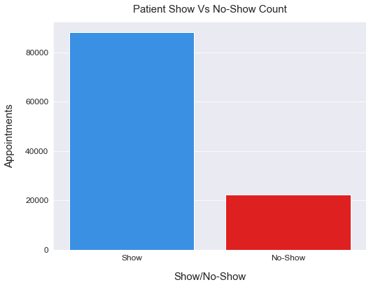

```python
# let's plot our target variable

plt.figure(figsize=(8,6))
sns.countplot(data=df, x='no_show', palette=['dodgerblue','red'])

plt.title('Patient Show Vs No-Show Count', fontsize=15, y=1.02)
plt.xlabel('Show/No-Show', fontsize=15,labelpad=15)
plt.ylabel('Appointments',  fontsize=15, labelpad=15)

x=[0,1]
labels=['Show','No-Show']
plt.xticks(x,labels,fontsize=12)
plt.yticks(fontsize=12);
```

- From the above plot above we can say that nearly 20% of the appointments were a no-show. Let's get more concreate numbers.

```python
print("No. of appointments made :", df.shape[0])
print("No. of appointments that were a No-Show :", df[df.no_show==1].shape[0])
print("Proportion of Show Vs No-Show :", round(df[df.no_show==0].shape[0]/df.shape[0],3),"Vs", round(df[df.no_show==1].shape[0]/df.shape[0],3) )
```

```
No. of appointments made : 110327
No. of appointments that were a No-Show : 22278
Proportion of Show Vs No-Show : 0.798 Vs 0.202
```

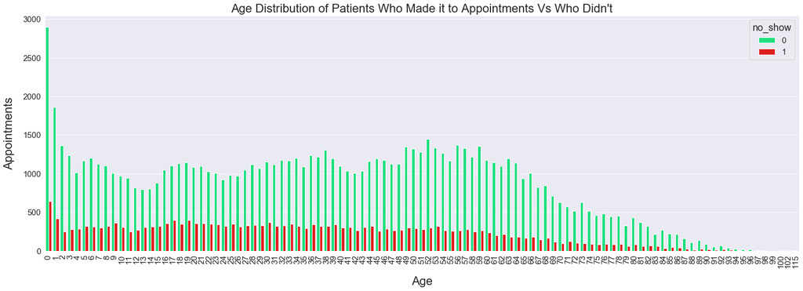

```python
# let's see the age distribution of patients who made it to appointments Vs who didn't.

plt.figure(figsize=(25,8))
sns.countplot(data=df, x='age', hue='no_show', palette=["springgreen", "red"])

plt.title("Age Distribution of Patients Who Made it to Appointments Vs Who Didn't", fontsize=22)
plt.xlabel('Age', fontsize=22, labelpad=15)
plt.ylabel('Appointments',  fontsize=22, labelpad=15)


plt.xticks(fontsize=15, rotation=90)
plt.yticks(fontsize=15)
plt.legend(title= 'no_show',title_fontsize=18,fontsize=15, loc="upper right");
```

- We see that patients with age range of 0 to 1 have high rate of showing up on appointment.
- They also have a high rate of not showing up on appointment.

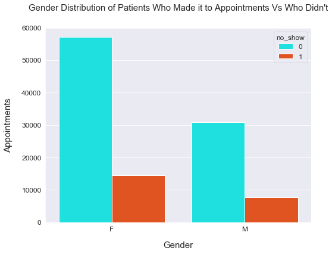

```python
# let's see the gender distribution of patients who made it to appointments Vs who didn't.

plt.figure(figsize=(8,6))
sns.countplot(data=df, x='gender', hue='no_show', palette=["aqua", "orangered"])

plt.title("Gender Distribution of Patients Who Made it to Appointments Vs Who Didn't", fontsize=15, y=1.07)
plt.xlabel('Gender', fontsize=15, labelpad=15)
plt.ylabel('Appointments',  fontsize=15,labelpad=15)


plt.xticks(fontsize=12)
plt.yticks(fontsize=12)
plt.legend(title= 'no_show',title_fontsize=12,fontsize=12, loc="upper right");
```

- Female patients have made twice as much appointments as males. Females aim to visit doctors nearly 2 times than male.
- However, both miss their appointments nearly equally.

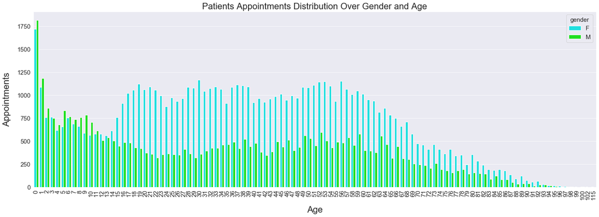

```python
# let's further explore and see if there is any correlation between age and gender.

plt.figure(figsize=(25,8))
sns.countplot(data=df, x='age', hue='gender', palette=["aqua", "lime"])

plt.title("Patients Appointments Distribution Over Gender and Age", fontsize=22)
plt.xlabel('Age', fontsize=22, labelpad=15)
plt.ylabel('Appointments',  fontsize=22, labelpad=15)


plt.xticks(fontsize=15, rotation=90)
plt.yticks(fontsize=15)
plt.legend(title= 'gender',title_fontsize=15,fontsize=15, loc="upper right");
```

- From the above plot we can say that, up untill the age around 15 males visit the doctors more than females.
- After age 15, females visit the doctors more than males.

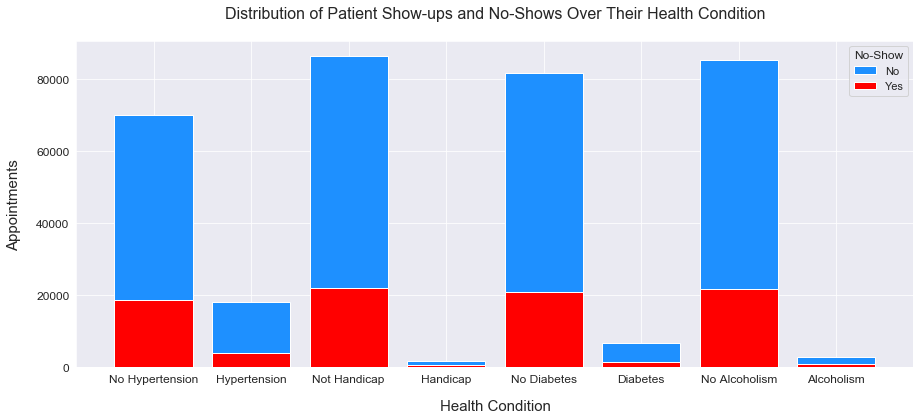

```python
# Let'see how does health condition of a patient impacts no_shows.

plt.figure(figsize=(15,6))
a=[]
df2=df[df['no_show']==0]
for i in ['hypertension','handicap','diabetes','alcoholism' ]:
    a.extend(df2[i].value_counts())

b=[]
df2=df[df['no_show']==1]
for i in ['hypertension','handicap','diabetes','alcoholism' ]:
    b.extend(df2[i].value_counts())

labels=['No Hypertension','Hypertension','Not Handicap','Handicap','No Diabetes','Diabetes','No Alcoholism','Alcoholism' ]
plt.bar([1,2,3,4,5,6,7,8],a, tick_label=labels, label='No', color='dodgerblue')
plt.bar([1,2,3,4,5,6,7,8],b, tick_label=labels, label='Yes', color='red')

plt.title("Distribution of Patient Show-ups and No-Shows Over Their Health Condition", fontsize=16, y=1.05)
plt.xlabel('Health Condition', fontsize=15, labelpad=15)
plt.ylabel('Appointments',  fontsize=15, labelpad=15)
plt.xticks(fontsize=12, rotation=0)
plt.yticks(fontsize=12)
plt.legend(title= 'No-Show',title_fontsize=12,fontsize=11, loc="upper right");
```

- Most common health condition among patients is Hypertension, followed by Diabetes, Alcoholism and Handicap.
- Patients with hypertension health condition have highest quantum of No-shows, again followed by Diabetes, Alcoholism and Handicap.

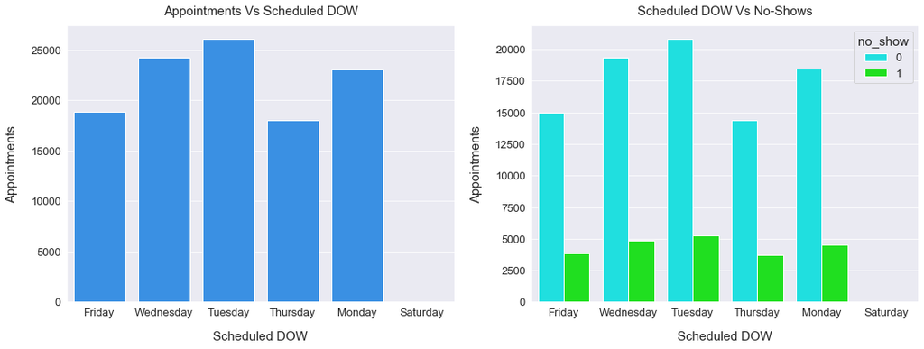

```python
# let's see how scheduled day of the week compare with no_shows.

plt.subplots(figsize=(18,6))

plt.subplot(1,2,1)
sns.countplot(data=df, x='scheduled_dow', palette=['dodgerblue'])

plt.title("Appointments Vs Scheduled DOW", fontsize=15,y=1.02)
plt.xlabel('Scheduled DOW', fontsize=15, labelpad=15)
plt.ylabel('Appointments',  fontsize=15, labelpad=15)
plt.xticks(fontsize=13, rotation=0)
plt.yticks(fontsize=13)

plt.subplot(1,2,2)
sns.countplot(data=df, x='scheduled_dow', hue='no_show', palette=["aqua", "lime"])

plt.title("Scheduled DOW Vs No-Shows", fontsize=15,y=1.02)
plt.xlabel('Scheduled DOW', fontsize=15, labelpad=15)
plt.ylabel('Appointments',  fontsize=15, labelpad=15)
plt.xticks(fontsize=13, rotation=0)
plt.yticks(fontsize=13)
plt.legend(title= 'no_show',title_fontsize=15,fontsize=13, loc="upper right");
```

- Most appointments are registered on Tuesday, followed by Wednesday and Monday.
- Almost zero appointments are made on Saturday. Sunday is a holiday, ofcourse.
- Most Shows/No-shows happened on Tuesday followed by Wednesday and Monday.
- Least No-shows happened on Thursday.

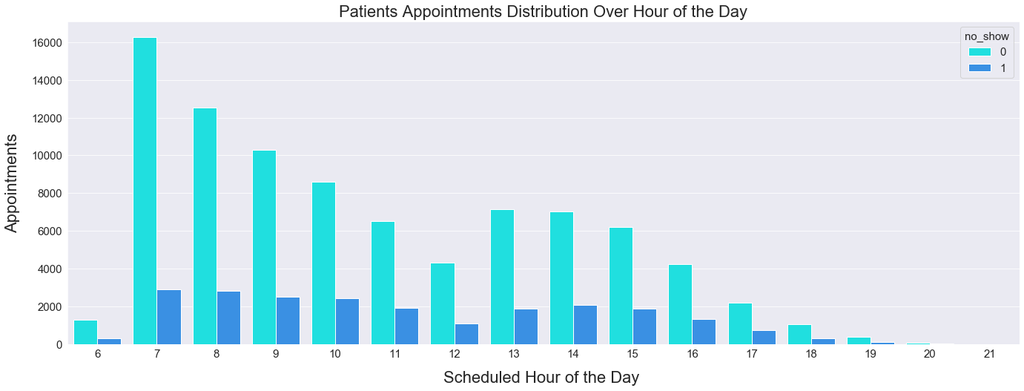

```python
# let's see which hour of the day receives most appointments.

plt.figure(figsize=(23,8))
sns.countplot(data=df, x='scheduled_hod',hue='no_show', palette=["aqua", "dodgerblue"])

plt.title("Patients Appointments Distribution Over Hour of the Day", fontsize=22)
plt.xlabel('Scheduled Hour of the Day ', fontsize=22, labelpad=15)
plt.ylabel('Appointments',  fontsize=22, labelpad=15)


plt.xticks(fontsize=15, rotation=0)
plt.yticks(fontsize=15)
plt.legend(title= 'no_show',title_fontsize=15,fontsize=15, loc="upper right");
```

- Most appointments are registered at 7 AM. Half of the appointments are registered between 07:00 AM -10:00AM.
- No appointments are registered after 10:00 PM up untill 6:00 AM
- Scheduled Hour of the day doesn't seem to have any correlation with No-Shows.

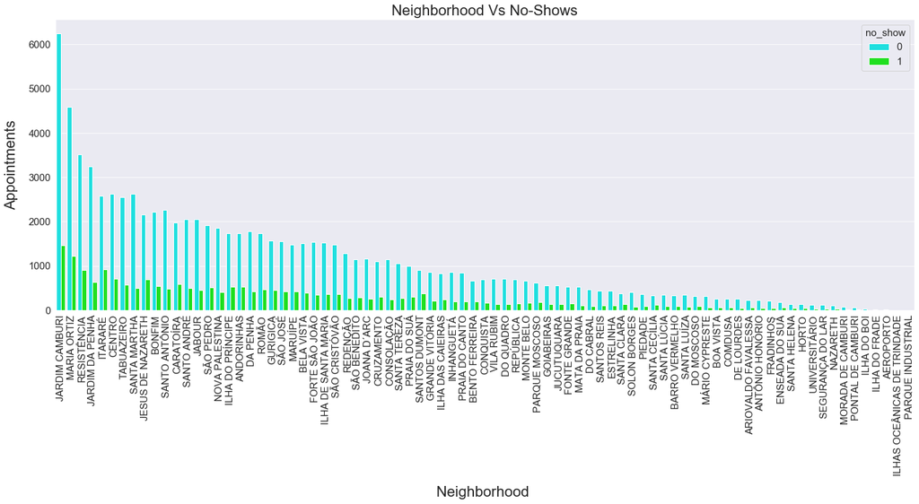

```python
# let's see if there is an impact of the neighborhood on no_shows.


plt.figure(figsize=(23,8))
sns.countplot(data=df,x='neighborhood',hue='no_show', palette=["aqua","lime"],order=df.neighborhood.value_counts().index)

plt.title("Neighborhood Vs No-Shows", fontsize=22)
plt.xlabel('Neighborhood ', fontsize=22, labelpad=15)
plt.ylabel('Appointments',  fontsize=22, labelpad=15)


plt.xticks(fontsize=15, rotation=90)
plt.yticks(fontsize=15)
plt.legend(title= 'no_show',title_fontsize=15,fontsize=15, loc="upper right");
```

- Top 3 neighborhood with the most Appointments and the No-shows as well: JARDIM CAMBURI', 'MARIA ORTIZ', 'RESISTÊNCIA'
- Neighborhood of the patient doesn't seem to have any direct correlation with No-Shows.

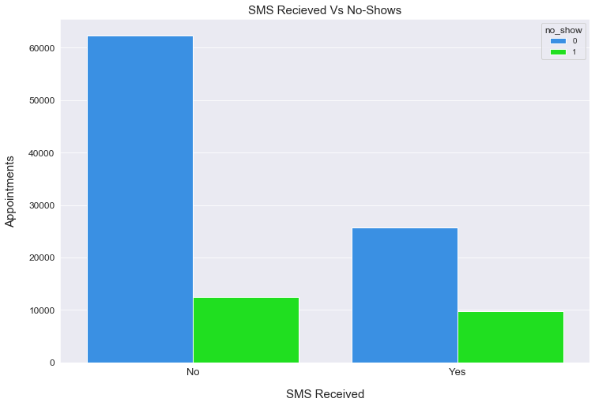

```python
# let' see what is the impact of sending the sms messages to the patient on no_shows.

plt.figure(figsize=(12,8))
sns.countplot(data=df,x='sms_received',hue='no_show', palette=["dodgerblue","lime"])


plt.title("SMS Recieved Vs No-Shows", fontsize=15)
plt.xlabel('SMS Received', fontsize=15, labelpad=15)
plt.ylabel('Appointments',  fontsize=15, labelpad=15)

x=[0,1]
labels=['No','Yes']
plt.xticks(x,labels,fontsize=13, rotation=0)
plt.yticks(fontsize=12)
plt.legend(title= 'no_show',title_fontsize=12,fontsize=10, loc="upper right");
```

- Sending SMS doesn't seem to increase the patients show up on appointment.
- Infact, the no. of patients who didn't received any SMS and showed up is manny times greater than the patients who did receive the SMS.

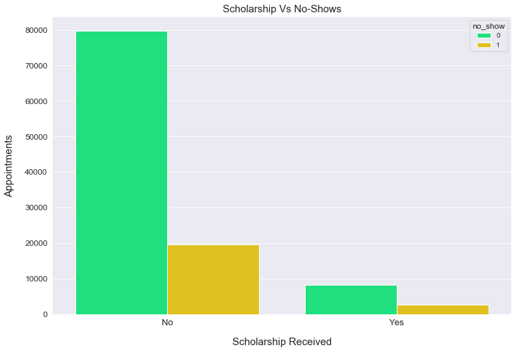

```python
# let' see what is the impact of having scholarship on patient no_shows.


plt.figure(figsize=(12,8))
sns.countplot(data=df,x='scholarship',hue='no_show', palette=["springgreen","gold"])


plt.title("Scholarship Vs No-Shows", fontsize=15)
plt.xlabel('Scholarship Received', fontsize=15, labelpad=15)
plt.ylabel('Appointments',  fontsize=15, labelpad=15)

x=[0,1]
labels=['No','Yes']
plt.xticks(x,labels,fontsize=13, rotation=0)
plt.yticks(fontsize=12)
plt.legend(title= 'no_show',title_fontsize=12,fontsize=10, loc="upper right");
```

- A very little no. of patients have scholarship.
- Nearly 80% of the patients without scholarship have a show up.
- nearly 70% of the patients with a scholarship have a show up.

### Conclusions:

We collected following data points/findings from our analysis:

- On average one patient has made two appointments.
- Nearly 20% of the appointments were a no-show.
- Patients with age range of 0 to 1 have high rate of showing up on appointment.
- They also have a high rate of not showing up on appointment.
- Female patients have made twice as much appointments as males. Females aim to visit doctors nearly 2 times than male.
- However, both miss their appointments nearly equally.
- Up untill the age around 15 males visit the doctors more than females.
- After age 15, females visit the doctors more than males.
- Most common health condition among patients is Hypertension, followed by Diabetes, Alcoholism and Handicap.
- Patients with hypertension health condition have highest quantum of No-shows, again followed by Diabetes, Alcoholism and Handicap.
- Most appointments are registered on Tuesday, followed by Wednesday and Monday.
- Almost zero appointments are made on Saturday. And, Sunday is a holiday, ofcourse.
- Most Shows/No-shows happened on Tuesday followed by Wednesday and Monday.
- Least No-shows happened on Thursday.
- Most appointments are registered at 7 AM. Half of the appointments are registered between 07:00 AM -10:00AM.
- No appointments are registered after 10:00 PM up untill 6:00 AM
- Scheduled Hour of the day doesn't seem to have any correlation with No-Shows.
- Top 3 neighborhood with the most Appointments and the No-shows as well: JARDIM CAMBURI', 'MARIA ORTIZ', 'RESISTÊNCIA'
- Neighborhood of the patient doesn't seem to have any direct correlation with No-Shows.
- Sending SMS doesn't seem to increase the patients show up on appointment.
- Infact, the no. of patients who didn't received any SMS and showed up is manny times greater than the patients who did receive the SMS.
- A very little no. of patients have scholarship.
- Nearly 80% of the patients without scholarship have a show up.
- nearly 70% of the patients with a scholarship have a show up.

#### Limitations:

- The dataset explored spans over 40 days only and may not exhibit true relationship between variables explored. Data with longer timeframe like an year or so would provide more real-world and true insights.
- The dataset is short on the influencer variable such as traffic and weather etc, which might impact the No-shows largely in some cases.
- No statistical methods are used in the analysis, which might give more concreate conclusions.